# HW#2_e4_main

## Exercise 4. PCA + Multinomial Regression

### (a) Perform a PCA on the attribute data of the safety ocutcome of body part - show the Eigen spectrum and the leading four Eigen vectors

*bpartbin* is the categorical variable vector *Xpredictors* are the 20 most relevant variables to body part safety This data is obtained from the source file included at the end of the exercise.

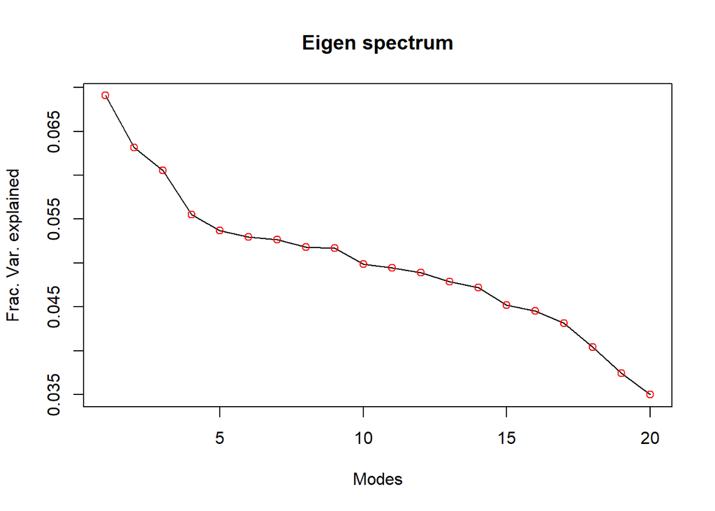

```r
zsvd = Xpredictors %>% scale(.) %>% var(.) %>% svd(.) # scale # get variance # Eigen decomposition
pcs=t(t(zsvd$u) %*% t(scale(Xpredictors))) #Principal Components...
lambdas=(zsvd$d/sum(zsvd$d)) #Eigen Values.. - fraction variance explained

plot(1:20, lambdas[1:20], type="l", xlab="Modes", ylab="Frac. Var. explained",main="Eigen spectrum") #plot spectrum
points(1:20, lambdas[1:20], col="red")
```

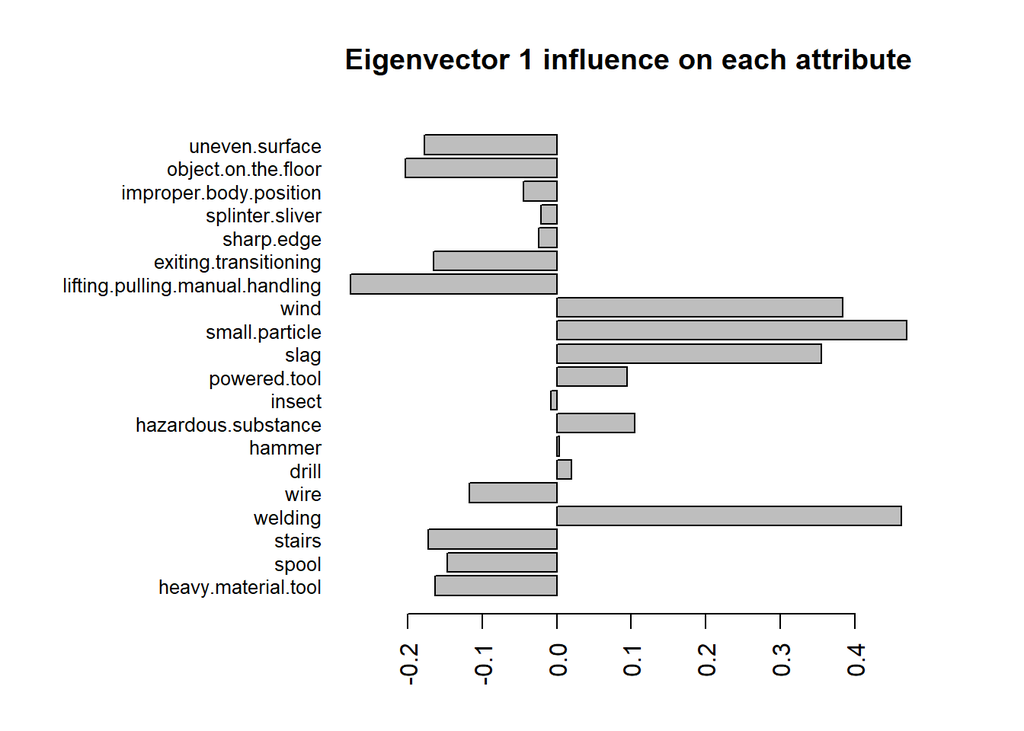

```
## [1] "Most influential attributes eigenvector 1: small.particle / welding / wind / slag"
```

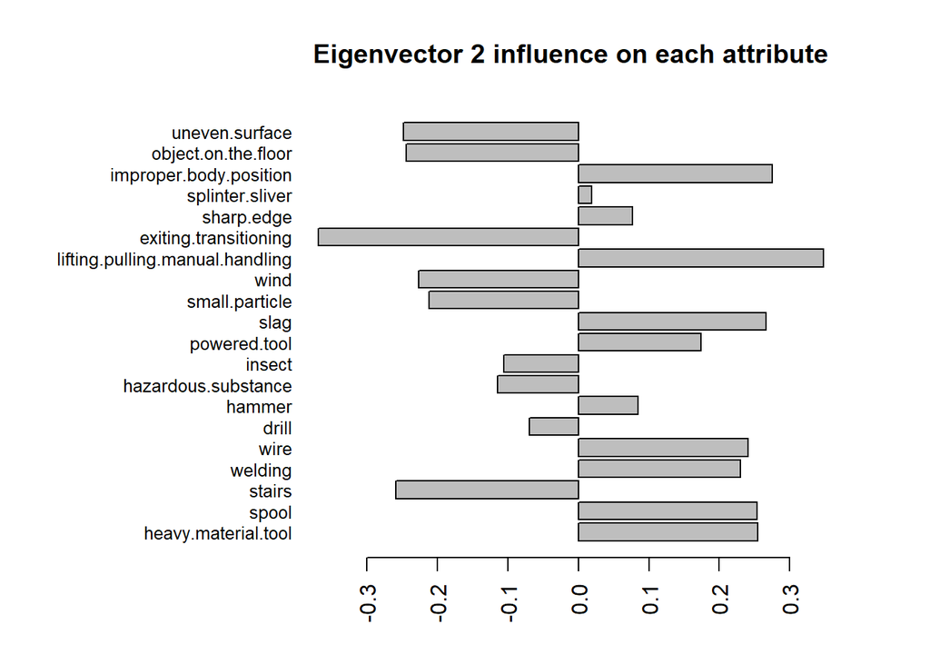

```
## [1] "Most influential attributes eigenvector 2: exiting.transitioning / lifting.pulling.manual.handling / improper.body.position / slag"
```

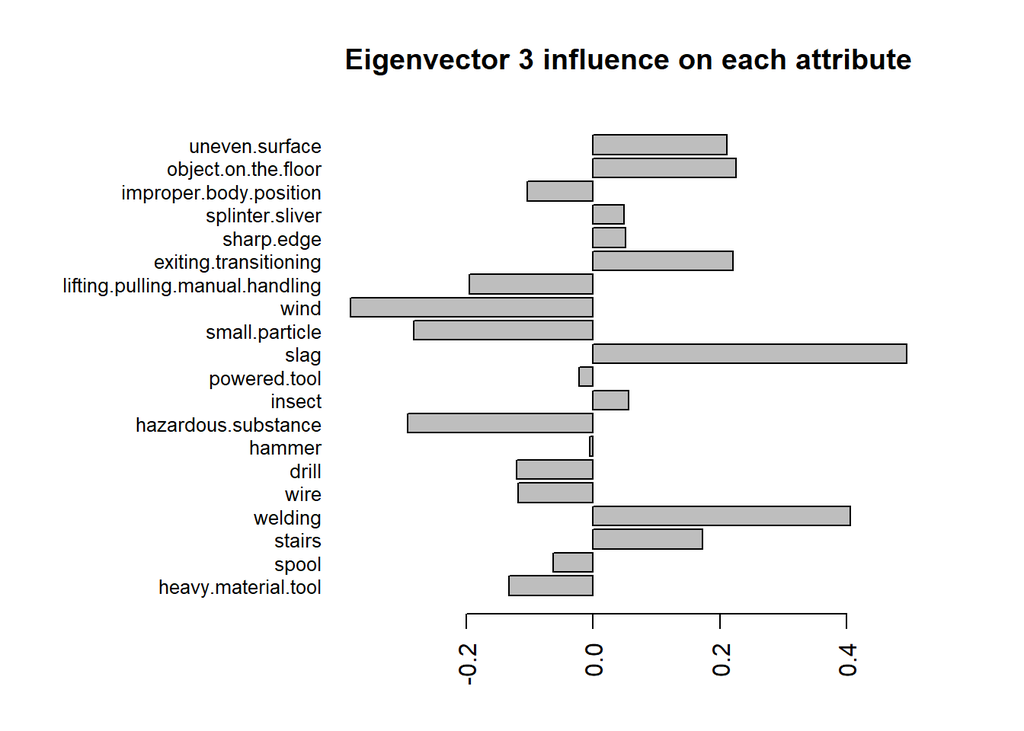

```
## [1] "Most influential attributes eigenvector 3: slag / welding / wind / hazardous.substance"
```

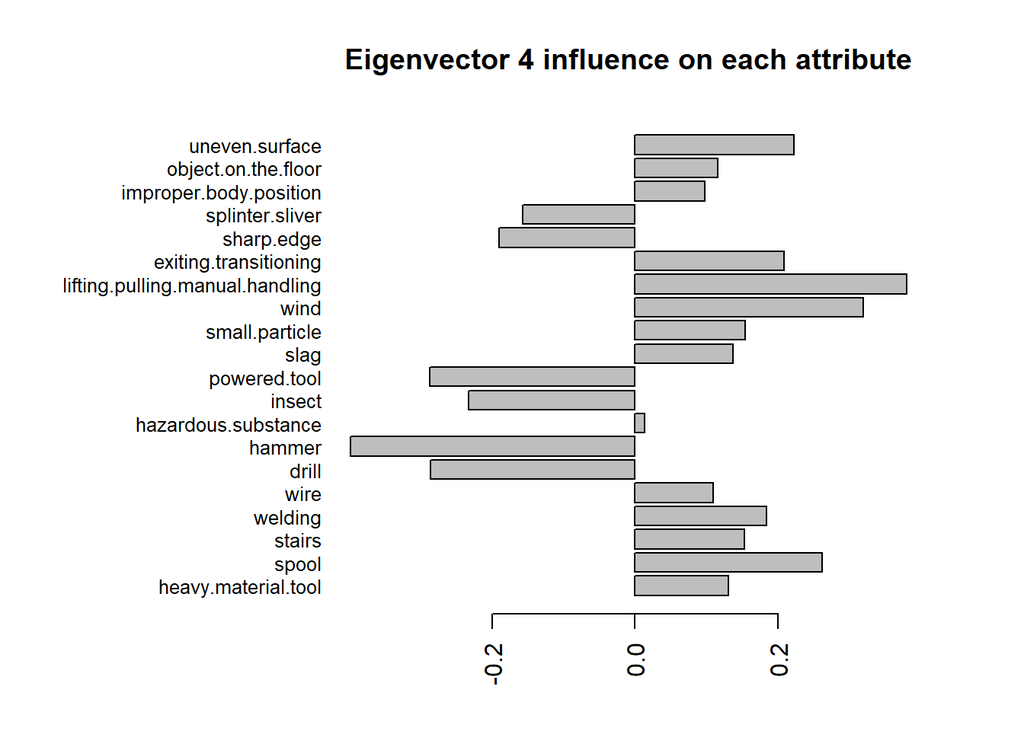

```
## [1] "Most influential attributes eigenvector 4: hammer / lifting.pulling.manual.handling / wind / powered.tool"
```

```r
par(las=2) # horizontal y - axis label
par(mar=c(4,12,4,4)) # increase y-axis margin.

for(i in 1:4){ # plot the four eigenvectors against each attribute
  barplot(zsvd$u[,i],main=paste("Eigenvector",i,"influence on each attribute"),names.arg = colnames(Xpredictors),horiz=TRUE,cex.names=0.8)
  indexmax=sort(abs(zsvd$u[,i]),decreasing = TRUE,index.return = TRUE) # sort eigen by largest values
  print(sprintf("Most influential attributes eigenvector %s: %s",i,paste(colnames(Xpredictors)[indexmax$ix[1:4]],collapse = " / "))) # print the four most influential attributes in eigenvector.
  }
```

### (b) Fit a best multinomial regression with the principal components as predictors to model the categorical probability of injuries to the five category of body parts and compute the RPSS

```r
pcs = cbind(data.frame(bpartbin),data.frame(pcs)) # dataset
zz = multinom(pcs$bpartbin ~ ., data = pcs[,1:6]) # Multinomial log-linear regression
N = log(length(bpartbin)) # penalty function for stepAIC

zbest=stepAIC(zz,k=N) # Check if the selected model is the best. It turns to be the best
```

```
## Start:  AIC=9909.6
## pcs$bpartbin ~ X1 + X2 + X3 + X4 + X5
##
##        Df     AIC
## <none>     9909.6
## - X5    4  9941.3
## - X2    4 10064.7
## - X4    4 10089.5
## - X3    4 10168.4
## - X1    4 10652.1
```

```r
# Prediction skill via RPSS
ypred = predict(zz, type = "probs") # prediction model

p.real=rep(NA,5) # Real probabilities
for(i in 1:5){
  p.real[i]=table(bpartbin)[i]/length(bpartbin)
}

rps(bpartbin,ypred,baseline = p.real)$rpss
```

```
## [1] 0.2611934
```

This score, RPSS, answers the question: What is the relative improvement of the probability forecast over body injury data in predicting the category that the observations fell into (p.real based on counts vs. multinom. regression prediction).

### (c) Repeat the process for Injury Severity data

*spartbin* is the categorical variable vector for injury severity data. Only 4 levels were found in the csv file despite being described as 6 in Tixier et al. (2016) *Xpredsev* are the 20 most relevant attributes to injury severity part. This data is obtained from the source file included at the end of the exercise.

#### PCA on the attribute data

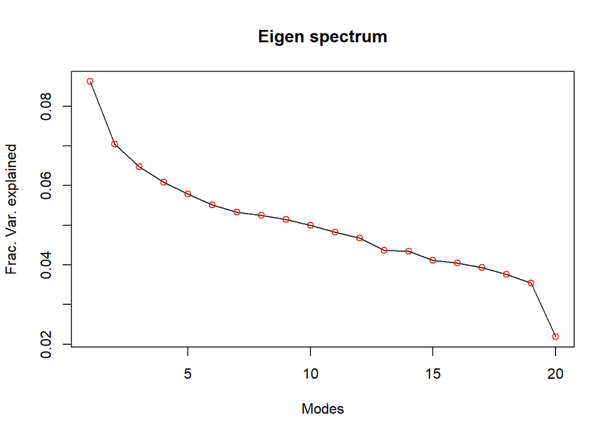

```r
zsvd = Xpredsev %>% scale(.) %>% var(.) %>% svd(.) # scale # get variance # Eigen decomposition
pcs=t(t(zsvd$u) %*% t(scale(Xpredsev))) #Principal Components...
lambdas=(zsvd$d/sum(zsvd$d)) #Eigen Values.. - fraction variance explained

plot(1:20, lambdas[1:20], type="l", xlab="Modes", ylab="Frac. Var. explained",main="Eigen spectrum") #plot spectrum
points(1:20, lambdas[1:20], col="red")
```

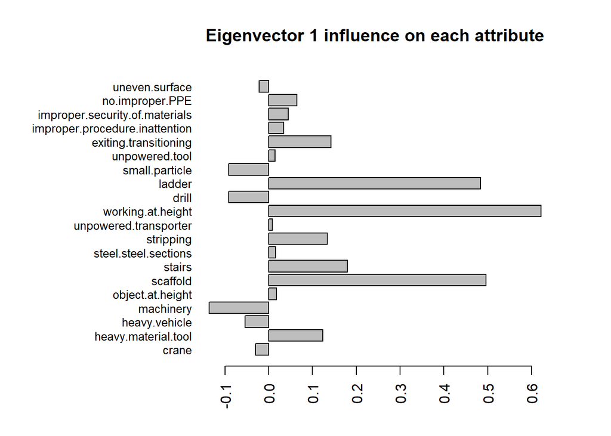

```
## [1] "Most influential attributes eigenvector 1: working.at.height / scaffold / ladder / stairs"
```

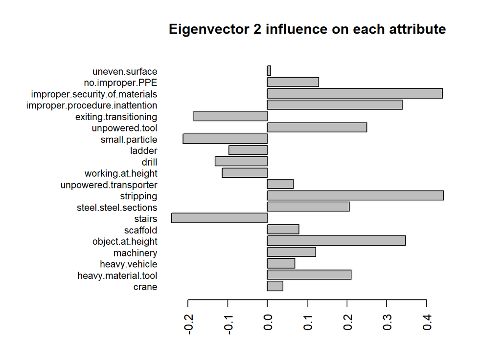

```
## [1] "Most influential attributes eigenvector 2: stripping / improper.security.of.materials / object.at.height / improper.procedure.inattention"
```

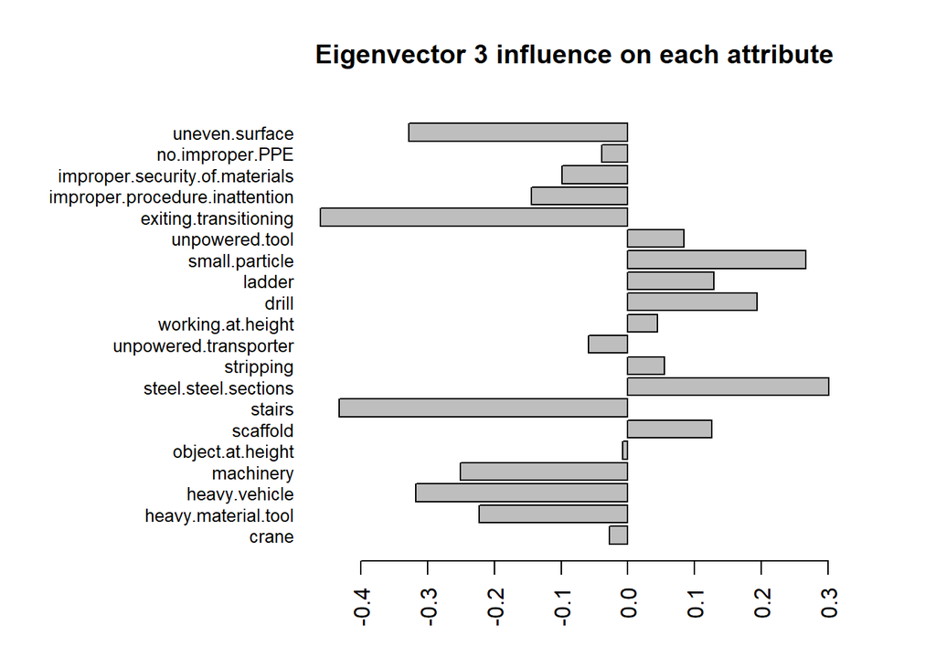

```
## [1] "Most influential attributes eigenvector 3: exiting.transitioning / stairs / uneven.surface / heavy.vehicle"
```

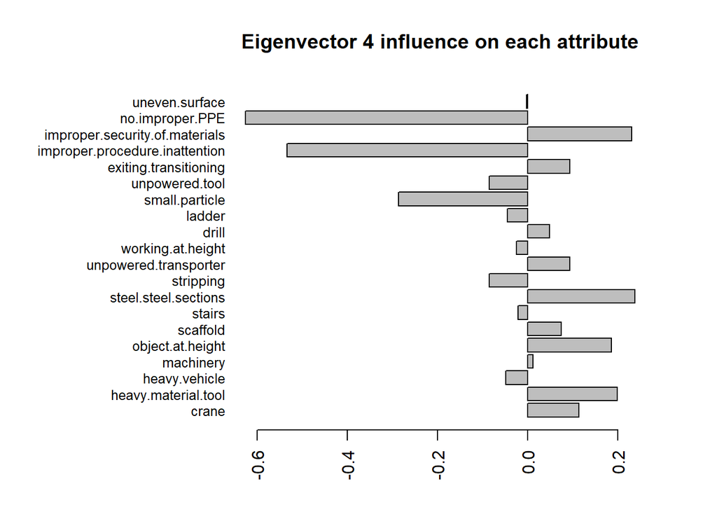

```
## [1] "Most influential attributes eigenvector 4: no.improper.PPE / improper.procedure.inattention / small.particle / steel.steel.sections"
```

```r
par(las=2) # horizontal y - axis label
par(mar=c(4,12,4,4)) # increase y-axis margin.

for(i in 1:4){ # plot the four eigenvectors against each attribute
  barplot(zsvd$u[,i],main=paste("Eigenvector",i,"influence on each attribute"),names.arg = colnames(Xpredsev),horiz=TRUE,cex.names=0.8)
  indexmax=sort(abs(zsvd$u[,i]),decreasing = TRUE,index.return = TRUE) # sort eigen by largest values
  print(sprintf("Most influential attributes eigenvector %s: %s",i,paste(colnames(Xpredsev)[indexmax$ix[1:4]],collapse = " / "))) # print the four most influential attributes in eigenvector.
  }
```

#### Best multinomial regression with the PCA as predictors to model the probability of injuries

```r
pcs = cbind(data.frame(spartbin),data.frame(pcs)) # dataset
zz = multinom(pcs$spartbin ~ ., data = pcs[,2:6]) # Multinomial log-linear regression
N = log(length(spartbin)) # penalty function for stepAIC

zbest=stepAIC(zz,k=N) # Check if the selected model is the best. A constant value is the best model
```

```
## Start:  AIC=3066.74
## pcs$spartbin ~ X1 + X2 + X3 + X4 + X5
##
##        Df    AIC
## - X5    3 3044.9
## - X1    3 3047.3
## - X4    3 3051.1
## - X2    3 3059.4
## <none>    3066.7
## - X3    3 3066.9
##
## Step:  AIC=3044.92
## pcs$spartbin ~ X1 + X2 + X3 + X4
##
##        Df    AIC
## - X1    3 3025.7
## - X4    3 3029.1
## - X2    3 3037.4
## <none>    3044.9
## - X3    3 3045.1
##
## Step:  AIC=3025.65
## pcs$spartbin ~ X2 + X3 + X4
##
##        Df    AIC
## - X4    3 3010.4
## - X2    3 3018.7
## <none>    3025.7
## - X3    3 3025.8
##
## Step:  AIC=3010.38
## pcs$spartbin ~ X2 + X3
##
##        Df    AIC
## - X2    3 3000.4
## - X3    3 3010.3
## <none>    3010.4
##
## Step:  AIC=3000.41
## pcs$spartbin ~ X3
##
##        Df    AIC
## - X3    3 2999.6
## <none>    3000.4
##
## Step:  AIC=2999.57
## pcs$spartbin ~ 1
```

```r
# Prediction skill via RPSS
ypred = predict(zz, type = "probs") # prediction model

p.real=rep(NA,4) # Real probabilities
for(i in 1:4){
  p.real[i]=table(spartbin)[i]/length(spartbin)
}

rps(spartbin,ypred,baseline = p.real)$rpss
```

```
## [1] 0.007163971
```

According to the definition of the RPSS the improvement given by the model is really low, as it happens to Tixier et al. (2016) due to imbalanced categories.

#### Aux code to call libraries, own functions and variables

```r
##
## Source Libraries
##
libr=c("magrittr","nnet","MASS","verification")
options(warn=-1)
suppressPackageStartupMessages(lapply(libr, require,character.only = TRUE))


##
## Source data
##

### Safety data
to.retain=20 # imp var to retain
imp.vars.energy=as.character(read.csv("gbm.importance.50.energy.csv",header=TRUE)[1:to.retain,"var"])
imp.vars.inj.type=as.character(read.csv("gbm.importance.50.code.csv",header=TRUE)[1:to.retain,"var"])
imp.vars.body=as.character(read.csv("gbm.importance.50.body.csv",header=TRUE)[1:to.retain,"var"])
imp.vars.severity=c("crane","heavy.material.tool","stairs","unpowered.tool","exiting.transitioning","heavy.vehicle","uneven.surface","drill","ladder","object.at.height","improper.procedure.inattention","unpowered.transporter","machinery","improper.security.of.materials","working.at.height","no.improper.PPE","small.particle","steel.steel.sections","stripping","scaffold")

# Body data
data.body = read.csv("data.body.part.csv")
index = data.body %>% {colnames(.) %in% imp.vars.body} %>% which(.)

Xpredictors = data.body[,index]

bpartbin = data.body[,1] %>% as.character(.)
bpartbin = bpartbin %>% {. == "head"} %>% replace(bpartbin, . , 1) %>% replace(., .== "neck", 2) %>% replace(., .== "trunk" , 3) %>% replace(., .== "upper extremities" , 4) %>% replace(., .== "lower extremities" , 5) %>% as.numeric(.) # Categorical variables

#Injury severity data
data.severity=read.csv("data.severity.csv")
index = data.severity %>% {colnames(.) %in% imp.vars.severity} %>% which(.)

Xpredsev = data.severity[,index]

spartbin = data.severity[,1] %>% as.character(.)
sevname=unique(spartbin)
spartbin = spartbin %>% {. == sevname[1]} %>% replace(spartbin, . , 1) %>% replace(., .== sevname[2], 2) %>% replace(., .== sevname[3] , 3) %>% replace(., .== sevname[4] , 4) %>% as.numeric(.) # Categorical variables



##
## Source functions
##
```